# Reproducible research : Course Project 1

Tarang Mehrotra

June 25, 2018

## R Markdown

Loading and preprocessing the data: We change the date column from Factor to date class.

```r
features <- read.csv('./activity.csv', header = T, sep = ',')

str(features)
```

```
## 'data.frame':    17568 obs. of  3 variables:
##  $ steps   : int  NA NA NA NA NA NA NA NA NA NA ...
##  $ date    : Factor w/ 61 levels "10/01/2012","10/02/2012",..: 1 1 1 1 1 1 1 1 1 1 ...
##  $ interval: int  0 5 10 15 20 25 30 35 40 45 ...
```

```r
features$date<-as.Date(features$date,"%m/%d/%Y")

str(features)
```

```
## 'data.frame':    17568 obs. of  3 variables:
##  $ steps   : int  NA NA NA NA NA NA NA NA NA NA ...
##  $ date    : Date, format: "2012-10-01" "2012-10-01" ...
##  $ interval: int  0 5 10 15 20 25 30 35 40 45 ...
```

## Including Plots

For calculating the total steps, date-wise after ignoring missing values.

```r
features1<-features[which(!(is.na(features$steps))),]

steps_total<-tapply(features1$steps,features1$date,sum)
```

Histogram of the total number of steps taken each day:

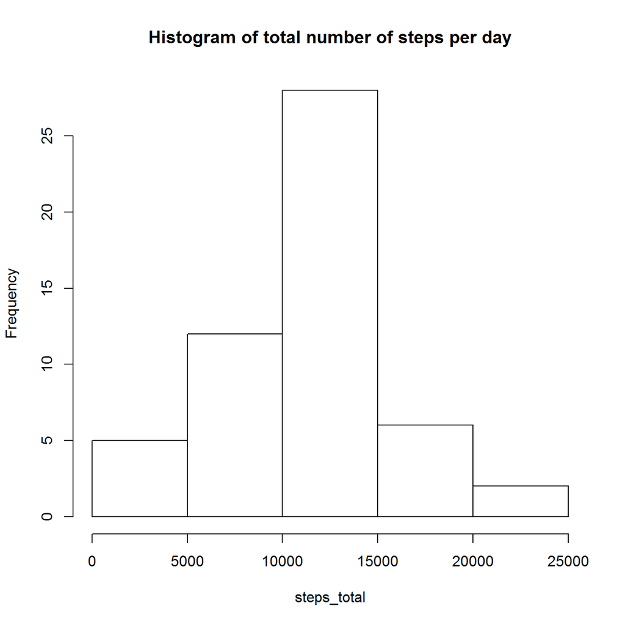

```r
hist(steps_total,main="Histogram of total number of steps per day")
```

To Calculate and report the mean and median of the total number of steps taken per day

Median:

```r
summary(steps_total)[3]
```

```
## Median
##  10765
```

Mean:

```r
summary(steps_total)[4]
```

```
##     Mean
## 10766.19
```

Time series plot(type=“l”) of the 5-minute interval (x-axis) and the average number of steps taken, averaged across all days:

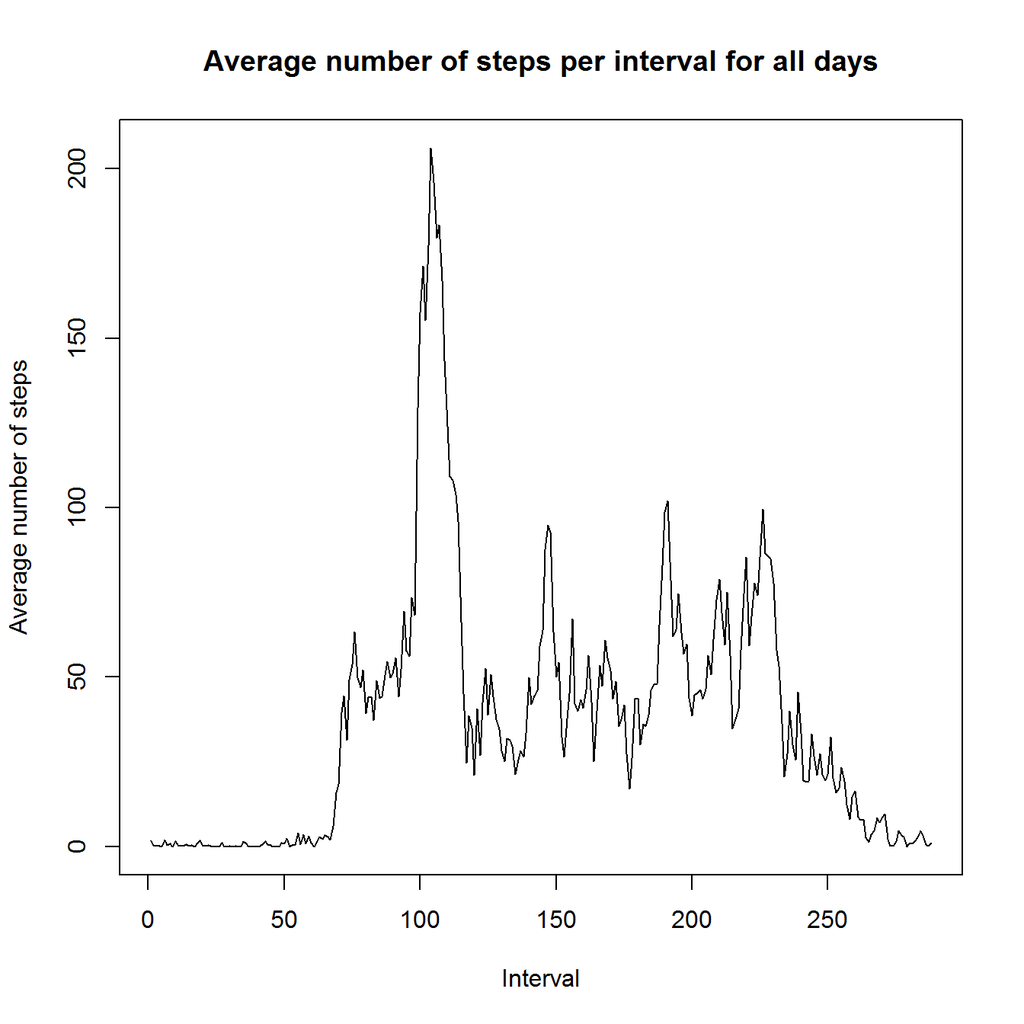

```r
steps_mean_interval<-tapply(features1$steps,features1$interval,mean)

plot(steps_mean_interval, type='l',
     main="Average number of steps per interval for all days", xlab="Interval",
     ylab="Average number of steps")
```

Which 5-minute interval, on average across all the days in the dataset, contains the maximum number of steps?

```r
which.max(steps_mean_interval)
```

```
## 835
## 104
```

Calculate and report the total number of missing values in the dataset (i.e. the total number of rows with NAs)

```r
v<-is.na(features)

sum(v)
```

```
## [1] 2304
```

Create a new dataset that is equal to the original dataset but with the missing data filled in with the average value of that interval:

```r
features3<-features

features3$steps[which((is.na(features3$steps)))] <- steps_mean_interval[which((is.na(features3$steps)))%%nrow(steps_mean_interval)]

steps_total_after_missing<-tapply(features3$steps,features3$date,sum)

steps_total_after_missing
```

```
## 2012-10-01 2012-10-02 2012-10-03 2012-10-04 2012-10-05 2012-10-06
##   10766.83     126.00   11352.00   12116.00   13294.00   15420.00
## 2012-10-07 2012-10-08 2012-10-09 2012-10-10 2012-10-11 2012-10-12
##   11015.00   10765.45   12811.00    9900.00   10304.00   17382.00
## 2012-10-13 2012-10-14 2012-10-15 2012-10-16 2012-10-17 2012-10-18
##   12426.00   15098.00   10139.00   15084.00   13452.00   10056.00
## 2012-10-19 2012-10-20 2012-10-21 2012-10-22 2012-10-23 2012-10-24
##   11829.00   10395.00    8821.00   13460.00    8918.00    8355.00
## 2012-10-25 2012-10-26 2012-10-27 2012-10-28 2012-10-29 2012-10-30
##    2492.00    6778.00   10119.00   11458.00    5018.00    9819.00
## 2012-10-31 2012-11-01 2012-11-02 2012-11-03 2012-11-04 2012-11-05
##   15414.00   10765.25   10600.00   10571.00   10765.26   10439.00
## 2012-11-06 2012-11-07 2012-11-08 2012-11-09 2012-11-10 2012-11-11
##    8334.00   12883.00    3219.00   10765.19   10767.21   12608.00
## 2012-11-12 2012-11-13 2012-11-14 2012-11-15 2012-11-16 2012-11-17
##   10765.00    7336.00   10765.64      41.00    5441.00   14339.00
## 2012-11-18 2012-11-19 2012-11-20 2012-11-21 2012-11-22 2012-11-23
##   15110.00    8841.00    4472.00   12787.00   20427.00   21194.00
## 2012-11-24 2012-11-25 2012-11-26 2012-11-27 2012-11-28 2012-11-29
##   14478.00   11834.00   11162.00   13646.00   10183.00    7047.00
## 2012-11-30
##   10765.98
```

Histogram of the new data with missing values replaced.

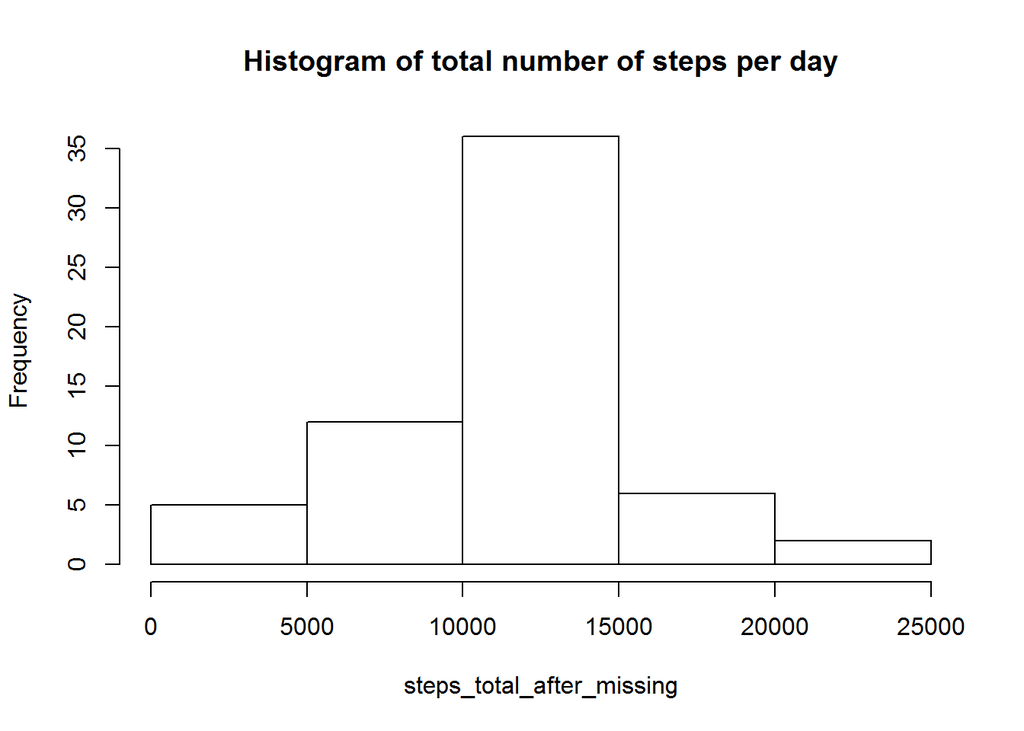

```r
hist(steps_total_after_missing,main="Histogram of total number of steps per day")
```

Mean and Median of the new data set:

```r
summary(steps_total_after_missing)
```

```
##    Min. 1st Qu.  Median    Mean 3rd Qu.    Max.
##      41    9819   10765   10766   12811   21194
```

Panel plot comparing the average number of steps taken per 5-minute interval across weekdays and weekends:

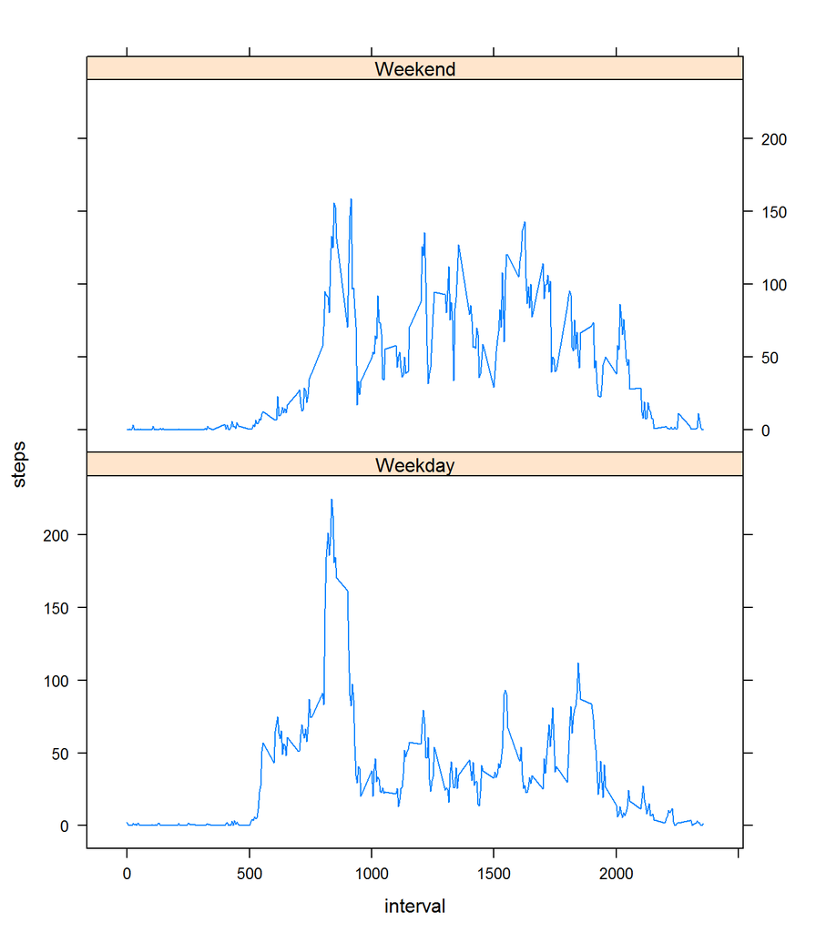

```r
library(lattice)

x<-(weekdays(features3$date,abbr = T ))
x<-gsub("S(at|un)","Weekend",x)
x<-gsub("Mon|Tue|Wed|Thu|Fri","Weekday",x)

features3$day<-as.factor(x)

avg_step_imp <- aggregate(steps ~ interval + day, data = features3, mean)

xyplot(steps~interval|day,data=avg_step_imp,layout(1,2),type = "l")
```